# IS609 -Math Modeling - HW3

J. Hamski

February 17, 2016

*Packages Used*

```r
library(ggplot2)
```

### 1

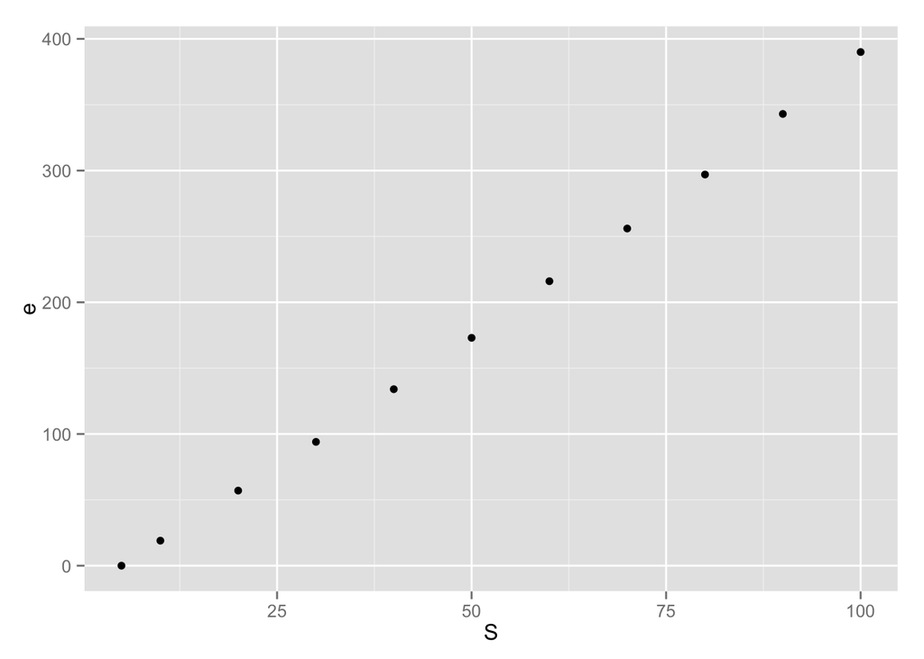

```r
S <- c(5, seq(10, 100, 10))
e <- c(0, 19, 57, 94, 134, 173, 216, 256, 297, 343, 390)

qplot(x = S, y = e)
```

### 2

```r
x <- c(1.0, 2.3, 3.7, 4.2, 6.1, 7.0)
y <- c(3.6, 3.0, 3.2, 5.1, 5.3, 6.8)
```

Using built-in least squares

```r
problems.2.ls.builtin <- lsfit(x = x, y = y, intercept = T)
problems.2.ls.builtin$coefficients
```

```
## Intercept         X
## 2.2148534 0.5642337
```

```r
problems.2.ls.builtin$residuals
```

```
## [1]  0.8209128 -0.5125910 -1.1025182  0.5153649 -0.3566791  0.6355105
```

Graphing the output

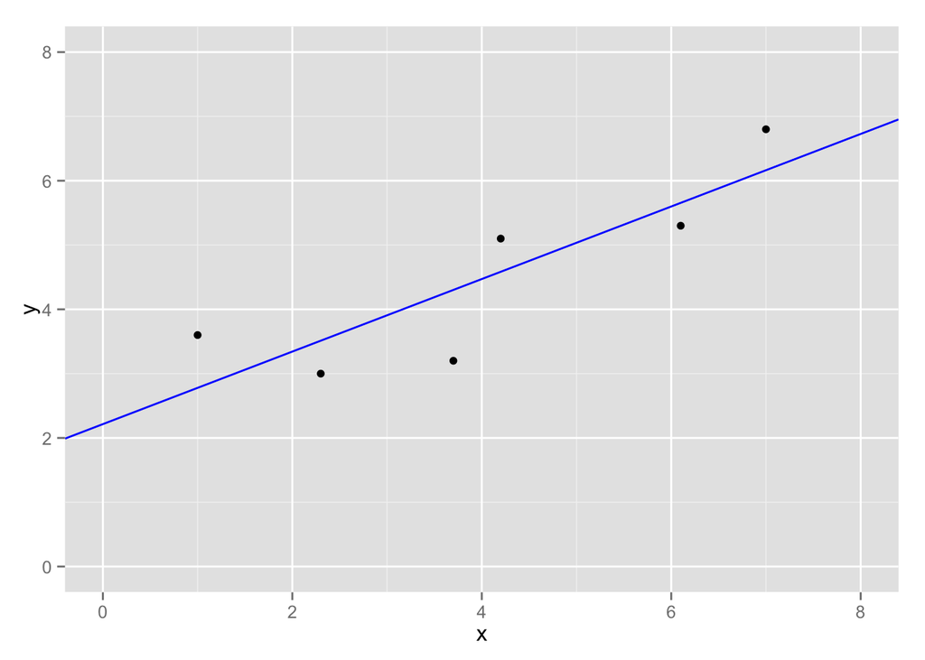

```r
qplot(x=x, y=y) + geom_abline(intercept=problems.2.ls.builtin$coefficients[1], slope=problems.2.ls.builtin$coefficients[2], color = "blue") + ylim(c(0,8)) + xlim (c(0,8))
```

### 3

```r
body <- c("Mercury", "Venus", "Earth", "Mars",
          "Jupiter", "Saturn", "Uranus", "Neptune")
period <- c(7.6e6, 1.94e7, 3.16e7,
            5.94e7, 3.74e8, 9.35e8,
            2.64e9, 5.22e9)
distance <- c(5.79e10, 1.08e11, 1.5e11,
              2.28e11, 7.79e11, 1.43e12,
              2.87e12, 4.5e12)
planets <- data.frame(body, period, distance)
```

Fit the model: $y=ax^{\frac{3}{2}}$

Which implies the Least Squares Criterion:
$$a=\frac{\sum x_i^{\frac{3}{2}} y_i}{\sum x_i^{3}}$$

```r
planets.a <- function(x, y, n){
  numerator <- sum((x ** n) * y)
  denominator <- sum(x ** (2*n))
  LS.planets <- numerator / denominator
  return(LS.planets)}

n = 3/2

a <- planets.a(planets$period, planets$distance, n)

planets.model <- function(a, x, n){
  model.distance <- a * (x ** n)
  return(model.distance)}

modeled.distance <- planets.model(a, planets$period, n)

planets.results <- cbind(planets, modeled.distance)
```

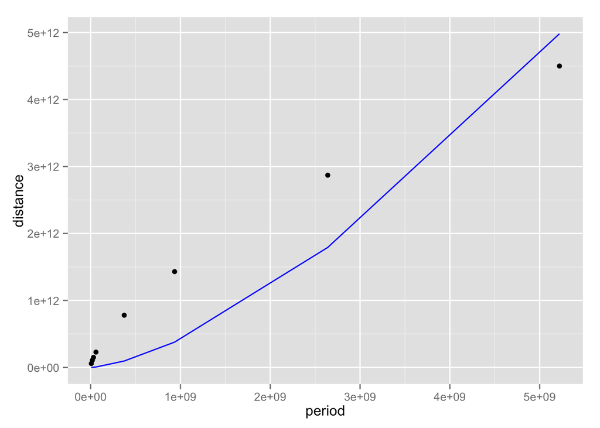

```r
ggplot(planets.results, aes(x = period, y = distance)) + geom_point() + geom_line(aes(x = period, y = modeled.distance), color = "blue")
```

### 4

```r
len <- c(14.5, 12.5, 17.25, 14.5, 12.625, 17.75, 14.125, 12.625)

wt <- c( 27, 17, 41, 26, 17, 49, 23, 16)

fish <- as.data.frame(cbind(len, wt))
```

#### A

Fit the model: $wt = k\cdot len^3$

```r
LS <- function(x, y, n){
  numerator <- sum((x ** n) * y)
  denominator <- sum(x ** (2*n))
  LS.result <- numerator / denominator
  return(LS.result)}

n = 3

k <- LS(fish$len, fish$wt, n)

fish.model <- function(k, x, n){
  model.distance <- k * (x ** n)
  return(model.distance)}

modeled.wt <- fish.model(k, fish$len, n)

fish.results <- cbind(fish, modeled.wt)
```

#### B

Fit the model: $wt = k \cdot l \cdot g^2$

```r
gr <- c(9.75, 8.3275, 11.0, 9.75, 8.5, 12.5, 9.0, 8.5)

fish <- cbind(fish, gr)
```

```r
LS.2 <- function(x, y, z, n){
  numerator <- sum((x ** n) * z * y)
  denominator <- sum(x ** (2*n))
  LS.result <- numerator / denominator
  return(LS.result)}

n.2 = 2

k <- LS.2(fish$len, fish$wt, fish$gr, n.2)

fish.model <- function(k, x, z, n){
  model.distance <- z * k * (x ** n)
  return(model.distance)}

modeled.wt.2 <- fish.model(k, fish$len, fish$gr, n)

fish.results <- cbind(fish.results, modeled.wt.2)
```

```r
fish.deviations.1 <- fish.results$wt - fish.results$modeled.wt

(D.max <- max(abs(fish.deviations.1)))
```

```
## [1] 2.305497
```

```r
(D.min <- sqrt(sum(fish.deviations.1**2)/length(fish.deviations.1)))
```

```
## [1] 1.233306
```

$$D = 1.233306 \leq c_{max} \leq 2.305497 = d_{max}$$

[figure not shown]

```r
ggplot(fish.results, aes(x = len, y = wt)) + geom_point() + geom_line(aes(x = len, y = modeled.wt), color = "blue") + labs(title = "Modeling Fish Weight using Length and Girth")
```

### 5

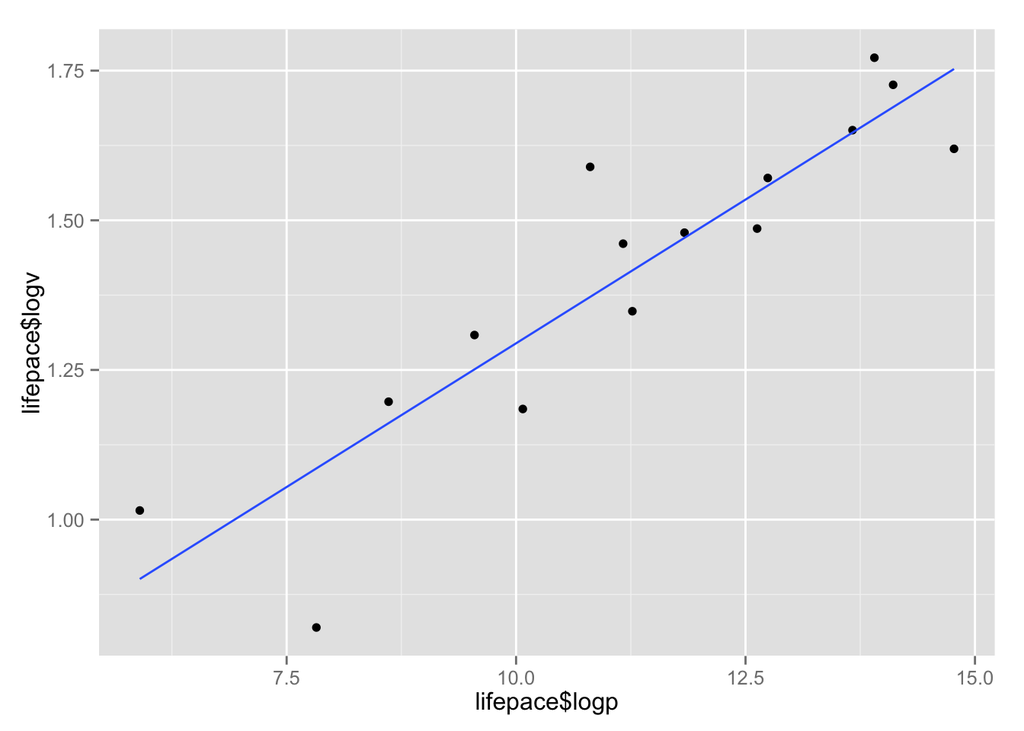

```r
lifepace <- read.csv("lifepace.csv", header = T)

lifepace$logp <- log(lifepace$Population)
lifepace$logv <- log(lifepace$Velocity)

qplot(x = lifepace$logp, y = lifepace$logv) + geom_smooth(method = "lm", se = F)
```

```r
(pacemodel.1 <- lm(logv ~ logp, data = lifepace))
```

```
##
## Call:
## lm(formula = logv ~ logp, data = lifepace)
##
## Coefficients:
## (Intercept)         logp
##     0.33418      0.09603
```

```r
pace.model <- function(P){pace.model.result <- 1.396*(P ** 0.096)}

lifepace$VelocityModel <- pace.model(lifepace$Population)
```

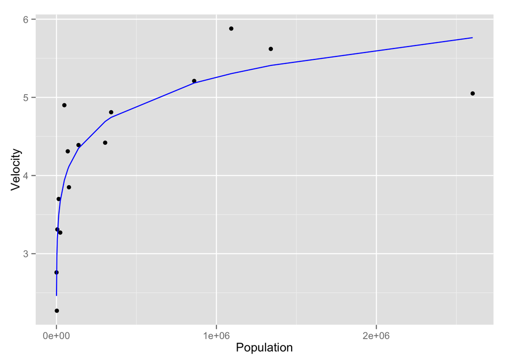

```r
(plot5.1 <- ggplot(lifepace, aes(x = Population, y = Velocity)) + geom_point() + geom_line(aes(x = Population, y = VelocityModel), color = "blue"))
```

The mean of the Bornstein errors is low, suggesting this is a good model.

```r
(b.errors <- mean(lifepace$Velocity - lifepace$VelocityModel))
```

```
## [1] 0.02662274
```

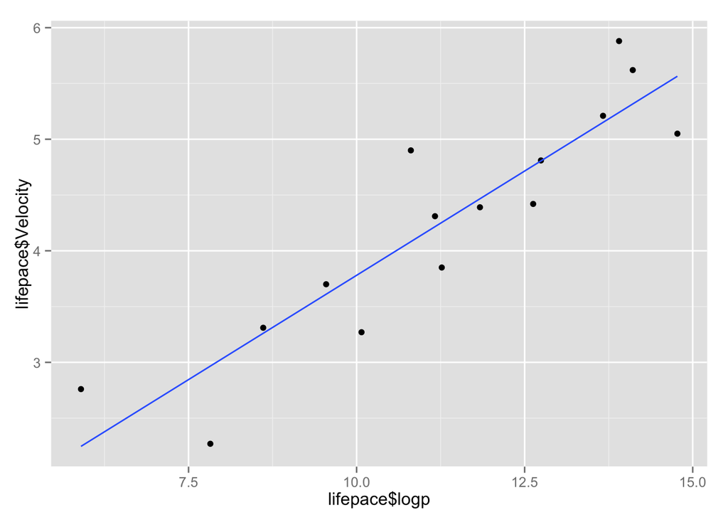

```r
qplot(x = lifepace$logp, y = lifepace$Velocity) + geom_smooth(method = "lm", se = F)
```

```r
(pacemodel.1 <- lm(Velocity ~ logp, data = lifepace))
```

```
##
## Call:
## lm(formula = Velocity ~ logp, data = lifepace)
##
## Coefficients:
## (Intercept)         logp
##     0.04042      0.37397
```

```r
pace.model.2 <- function(P){pace.model.result <- 0.37397*log(P)+0.04042}

lifepace$VelocityModel2 <- pace.model.2(lifepace$Population)
```

The mean of the Bornstein errors is even lower, suggesting this is an even better model!

```r
(b.errors <- mean(lifepace$Velocity - lifepace$VelocityModel2))
```

```
## [1] -5.54487e-05
```

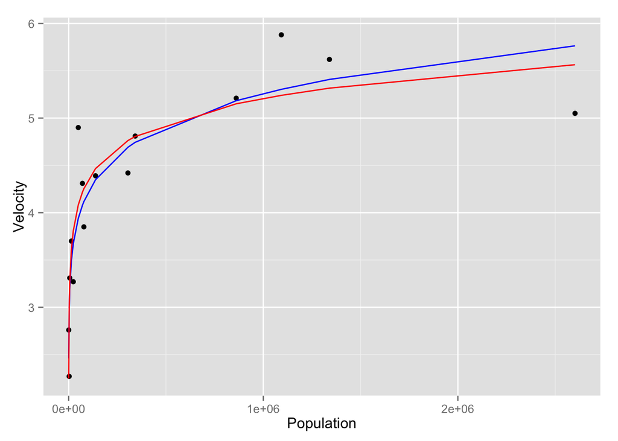

```r
(plot5.1 + geom_line(data = lifepace, aes(x = Population, y = VelocityModel2), color = "red"))
```

### 6

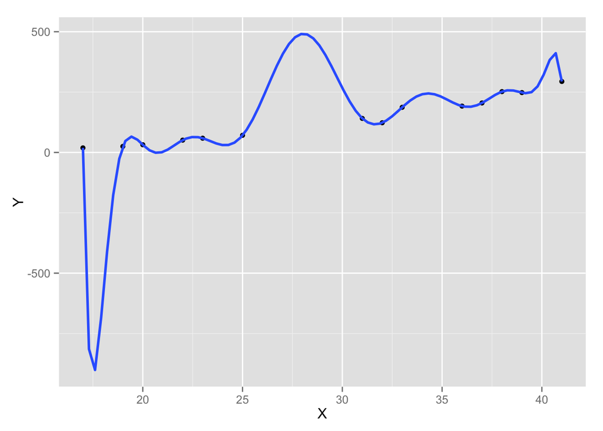

```r
pine <- read.csv("pine.csv", header = T)

ggplot(pine, aes(x=X, y=Y))+ geom_point() + stat_smooth(method = "lm", formula = y ~ poly(x, 13), size = 1)
```

This is not a good model for ponderosa pine diameter and volume. The severe oscillation does not match the real world phenomenon - jumping just a few inches in diameter will not change the volume orders of magnitude in any direction. Also, a negative volume is given by the model, which voilates the laws of tree-physics. The 13th order polynomial is an overfitted model.

### 7

```r
len <- c(12.5, 12.625, 14.125, 14.5, 17.25, 17.75)
wt <- c(17, 16.5, 23, 26.5, 41, 49)
bass <- as.data.frame(cbind(len, wt))
```

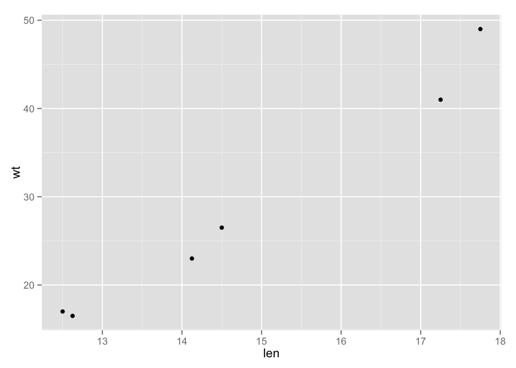

```r
qplot(x=len, y=wt)
```

There appears to be a positive correlation between Bass length and weight. There does not appear to be any outliers in the data.

```r
a.1 <- (bass[2,2]-bass[1,2]) / (bass[2,1] - bass[1,1])
a.2 <- (bass[3,2]-bass[2,2]) / (bass[3,1] - bass[2,1])
a.3 <- (bass[4,2]-bass[3,2]) / (bass[4,1] - bass[3,1])
a.4 <- (bass[5,2]-bass[4,2]) / (bass[5,1] - bass[4,1])
a.5 <- (bass[6,2]-bass[5,2]) / (bass[6,1] - bass[5,1])

div.diff <- rbind(a.1, a.2, a.3, a.4, a.5)
div.diff <- as.data.frame(div.diff)

b.1 <- (a.2 -a.1) / (bass[3,1] - bass[1,1])
b.2 <- (a.3 -a.2) / (bass[4,1] - bass[2,1])
b.3 <- (a.4 -a.3) / (bass[5,1] - bass[3,1])
b.4 <- (a.5 -a.4) / (bass[6,1] - bass[4,1])

b <- rbind(NA, b.1, b.2, b.3, b.4)
div.diff <- cbind(div.diff, b)

c.1 <- (b.2 - b.1) / bass[4,1] - bass[1,1]
c.2 <- (b.3 - b.2) / bass[5,1] - bass[2,1]
c.3 <- (b.4 - b.3) / bass[6,1] - bass[3,1]

c <- rbind(NA, c.1, c.2, c.3, NA)
div.diff <- cbind(div.diff, c)

d.1 <- (c.2 - c.1) / bass[5,1] - bass[1,1]
d.2 <- (c.3 - c.2) / bass[6,1] - bass[2,1]

d <- rbind(NA, NA, d.1, d.2, NA)
div.diff <- cbind(div.diff, d)

e.1 <- (d.2 - d.1) / bass[6,1] - bass[1,1]

e <- rbind(NA, NA, e.1, NA, NA)
div.diff <- cbind(div.diff, e)
div.diff
```

```
##            V1         b         c         d         e
## a.1 -4.000000        NA        NA        NA        NA
## a.2  4.333333  5.128205 -12.66976        NA        NA
## a.3  9.333333  2.666667 -12.85492 -12.51073 -12.50965
## a.4  5.272727 -1.299394 -13.86584 -12.68195        NA
## a.5 16.000000  3.300699        NA        NA        NA
```

*1st degree*

```r
f1.s <- summary(fit.1 <- lm(wt ~ len, data = bass))
(sum(sqrt(f1.s$residuals**2)))
```

```
## [1] 9.567189
```

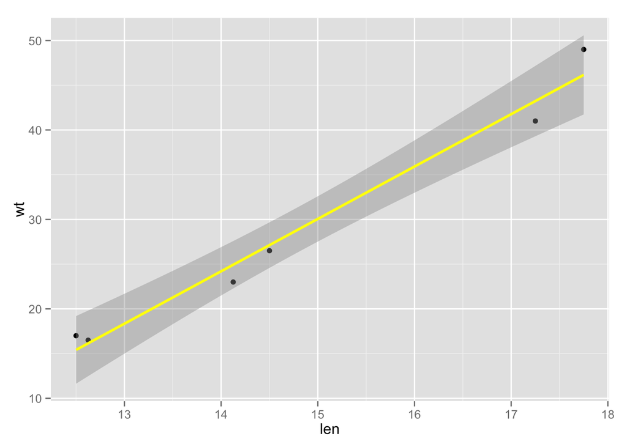

```r
ggplot(bass, aes(x=len, y=wt))+ geom_point() + stat_smooth(method = "lm", formula = y ~ poly(x, 1, raw=T), size = 1, color = "yellow")
```

*2nd degree*

```r
f2.s <- summary(fit.2 <- lm(wt ~ poly(len, 2, raw=T), data = bass))
(sum(sqrt(f2.s$residuals**2)))
```

```
## [1] 6.490142
```

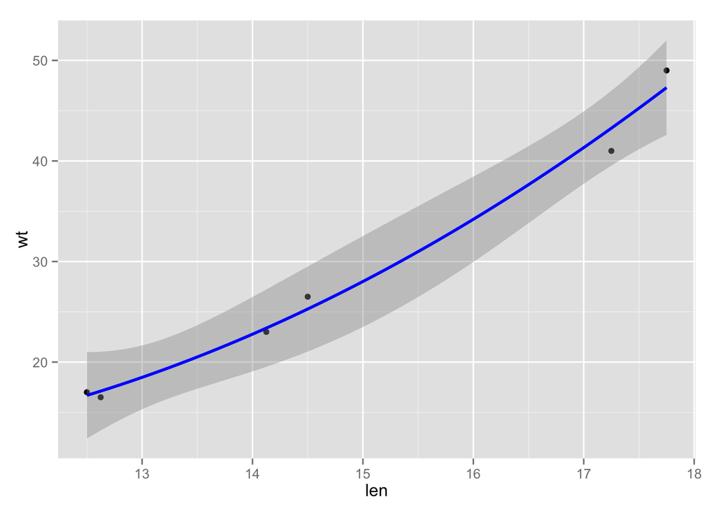

```r
ggplot(bass, aes(x=len, y=wt))+ geom_point() + stat_smooth(method = "lm", formula = y ~ poly(x, 2, raw=T), size = 1, color = "blue")
```

*3rd degree*

```r
f3.s <- summary(fit.3 <- lm(wt ~ poly(len, 3, raw=T), data = bass))
(sum(sqrt(f3.s$residuals**2)))
```

```
## [1] 4.773011
```

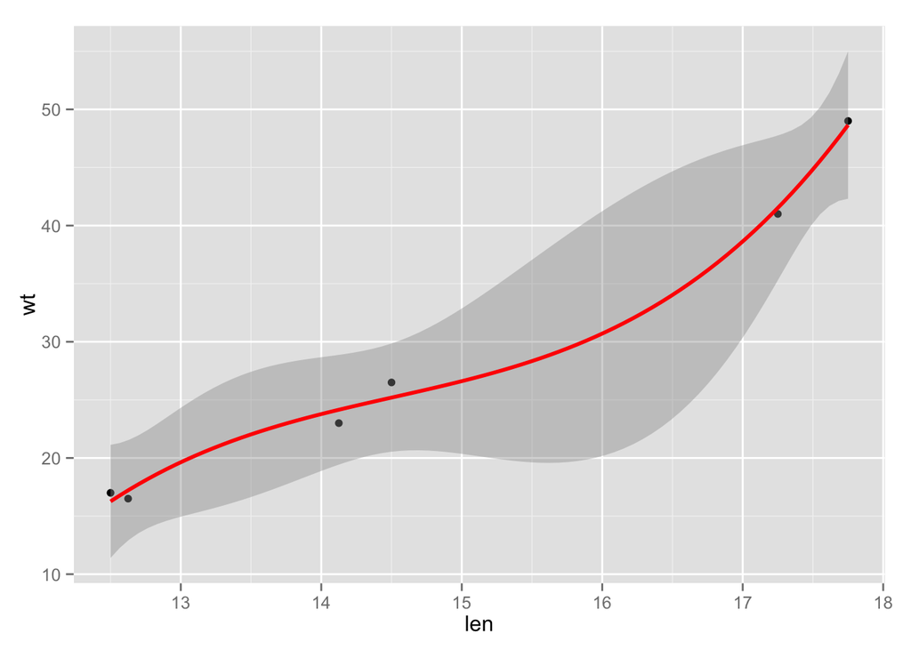

```r
ggplot(bass, aes(x=len, y=wt))+ geom_point() + stat_smooth(method = "lm", formula = y ~ poly(x, 3, raw=T), size = 1, color = "red")
```